# 기호 수학(Symbolic Math)

미적분학(calculus)

이광춘

[Tidyverse Korea](https://www.facebook.com/groups/tidyverse/)

2021-01-25

# 1 수능시험

인터넷에 공개된 “2020학년도 대학수학능력시험 문제 및 정답” PDF 문제를 풀어보자.

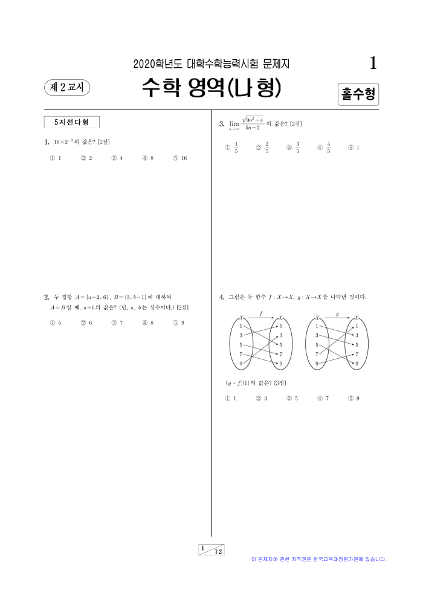

```r
library(tidyverse)
library(pdftools)
library(magick)

exam_pdf <- image_read_pdf("data/math_2020_2_1.pdf", page = 28)

exam_pdf %>%
  image_scale("700") %>%
  image_draw()
```

# 2 수식 추출

[mathpix](https://mathpix.com/) 소프트웨어를 사용하면 PDF 문서에서 수식을 추출하여 $\LaTeX$으로 쉽게 변환시킬 수 있다.

$$16 \times 2^{-3}$$

# 3 $\LaTeX$ → Sympy 표현식

앞서 추출한 $\LaTeX$ 수식표현을 Sympy 표현식으로 바꿔야한다. 이를 위해서 [`latex2sympy`](https://github.com/augustt198/latex2sympy)를 설치해서 사용하면 되지만, 파이썬 2로 작성되어 있어 파이썬3를 많이 사용해서 이를 확인할 필요가 있다.

```r
$ pip install latex2sympy3==0.1.1
```

# 4 Sympy 풀기

파이썬 표현식으로 작성하고 나서 이를 Sympy 문법 값을 구하는 `N()`을 사용해서 해를 구한다.

```python
from sympy import *

N(16 * 2**(- 3))
```

```
2.00000000000000
```

# 5 R/Sympy 코드 변환

## 5.1 $\LaTeX$ → R

[`latex2r`](https://github.com/tomicapretto/latex2r) 팩키지의 도움으로 $\LaTeX$ 코드를 R 코드로 변환시킨다.

```r
# devtools::install_github("tomicapretto/latex2r")
library(latex2r)

r_expr <- latex2r("16 \\times 2^{-3}")
```

R에서 `Sympy`를 통해 문제를 풀 수 있는 팩키지가 `caracas`, `rSympy`가 있다. [`caracas`](https://mikl.dk/post/2020-caracas_v101/)를 사용해서 문제를 풀면 다음과 같다.

```r
library(caracas)

caracas::eval_to_symbol(r_expr)
```

```
[caracas]: 2.0
```

[`rSympy`](https://kevinkotze.github.io/mm-tut1-symbolic/)를 사용해서 문제를 풀면 다음과 같다. `^` → `**`으로 바꿔 파이썬 표현식에 맞춰 넣어주면 `rSympy`로 해를 구할 수 있다. `rJavaTools`오류로 R마크다운 컴파일 오류지만 인터랙티브 계산은 됨!!!

```r
library(rSymPy)

sympy("16 * 2 ** (- 3)")
```

# 6 손으로 풀기

몇가지 방식으로 손으로 풀 수 있다.

$16 \times 2^{-3} = \frac{16}{2^3} = \frac{2^4}{2^3} = 2^{4-3} = 2$

$16 \times 2^{-3} = \frac{16}{2^3} = \frac{16}{8} = 2$

# 7 `SymPy Gamma` vs `Wolfram Alpha`

[SymPy Gamma](https://www.sympygamma.com/)는 [`Wolfram Alpha`](https://www.wolframalpha.com/)의 오픈소스 버전으로 보면 된다.

데이터 과학자 [이광춘](https://github.com/statkclee/) 저작

*kwangchun.lee.7@gmail.com*